# WEEK 2 SECONDARY PROJECT

HIERACHICAL CLUSTERING

```r
df2 <- scale(df_new)
head(df_new)
```

```
##   Administrative Administrative_Duration Informational Informational_Duration
## 1              0                       0             0                      0
## 2              0                       0             0                      0
## 3              0                      -1             0                     -1
## 4              0                       0             0                      0
## 5              0                       0             0                      0
## 6              0                       0             0                      0
##   ProductRelated ProductRelated_Duration BounceRates ExitRates PageValues
## 1              1                0.000000  0.20000000 0.2000000          0
## 2              2               64.000000  0.00000000 0.1000000          0
## 3              1               -1.000000  0.20000000 0.2000000          0
## 4              2                2.666667  0.05000000 0.1400000          0
## 5             10              627.500000  0.02000000 0.0500000          0
## 6             19              154.216667  0.01578947 0.0245614          0
##   SpecialDay OperatingSystems Browser Region
## 1          0                1       1      1
## 2          0                2       2      1
## 3          0                4       1      9
## 4          0                3       2      2
## 5          0                3       3      1
## 6          0                2       2      1
```

```r
rand_df <- df2[sample(nrow(df2), size=1500), ]
head(rand_df)
```

```
##      Administrative Administrative_Duration Informational
## 6882    -0.39659813             -0.40091600    -0.3966145
## 3476    -0.69755332             -0.45745776    -0.3966145
## 5632     0.50626741             -0.11594553    -0.3966145
## 6829    -0.39659813             -0.33758923     0.3903525
## 7019    -0.09564295             -0.03678707    -0.3966145
## 6815    -0.69755332             -0.45745776    -0.3966145
##      Informational_Duration ProductRelated ProductRelated_Duration BounceRates
## 6882             -0.2450294     -0.3992751           -0.2985854218  -0.4574391
## 3476             -0.2450294     -0.5341358           -0.5780155380  -0.4574391
## 5632             -0.2450294     -0.4667055           -0.3256613085  -0.4574391
## 6829              0.7562098     -0.5566126           -0.4639485707  -0.4574391
## 7019             -0.2450294      0.2300750            0.1493072056  -0.3591077
## 6815             -0.2450294     -0.4667055            0.0009208987  -0.4574391
##       ExitRates PageValues SpecialDay OperatingSystems    Browser      Region
## 6882 -0.5721407 -0.3173633  -0.309001       -0.1361914 -0.2081361 -0.89418405
## 3476  0.1441964 -0.3173633  -0.309001       -0.1361914 -0.2081361 -0.89418405
## 5632 -0.6113921 -0.3173633  -0.309001       -0.1361914 -0.2081361  1.60351486
## 6829 -0.8861515 -0.3173633  -0.309001       -0.1361914 -0.2081361 -0.89418405
## 7019 -0.7880231  2.0906614  -0.309001       -0.1361914 -0.2081361  1.60351486
## 6815 -0.6800819 -0.3173633  -0.309001       -0.1361914 -0.2081361 -0.06161775
```

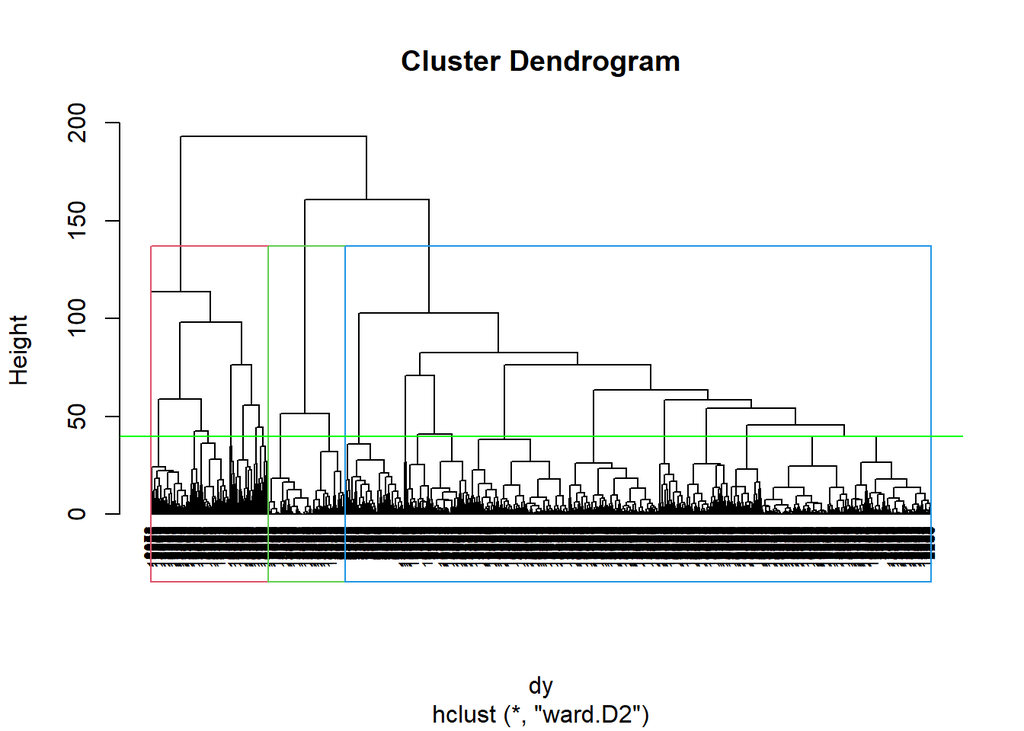

```r
dy <- dist(rand_df, method = "manhattan")
res.h <- hclust(dy, method = "ward.D2")
plot(res.h, cex=0.6, hang=-1)
rect.hclust(res.h , k =3, border = 2:6)
abline(h = 40, col = 'green')
```

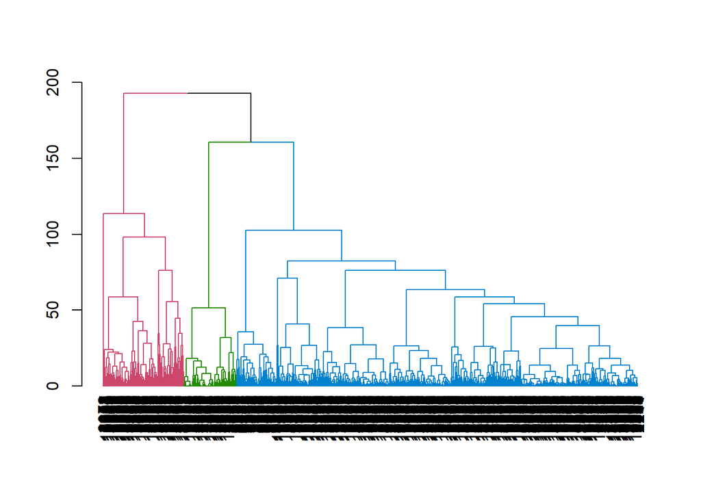

```r
suppressPackageStartupMessages(library(dendextend))
avg_dend_obj <- as.dendrogram(res.h)
avg_col_dend <- color_branches(avg_dend_obj, h = 150)
plot(avg_col_dend)
```

If we use a K of 3 we can see that we have blue as the biggest cluster followed by red then finally green.

Conclusion and reccomendation

1. Focus more on this three months because that where most customers visit any pages, March ,May and November
2. Returning visitors were the most common followed by the New visitors

4 1,2 and 3 were the most popular type of Traffic

6 From our hierarchical clustering If we use a K of 3 we can see that we have blue as the biggest cluster followed by red then finally green.